# Explore survey data for SEN

**author: Mary Fisher**

**date written: 2025-02-05**

## Description

Explore the survey data as prep for SEN research questions (analyzing fit - what scale; analyzing homophily, social capital in sn - what attributes). Particularly interested in:

1. How connected are counties by people who are primarily involved in kelp forest-related issues? <– set scale of SEN
2. Which organizations have individual responses by people who directly observe kelp, and/or collect and analyze data (info type)? Can I link these organizations to specific restoration sites within counties? <– set scale of SEN
3. What is the response rate and variation in how respondents are involved in kelp issues (tourism, research, etc)? <– set scale of SEN; is this a useful actor attribute to explore capital
4. What is the variation in responses on level of involvement in kelp forest issues (primarily, routinely, rarely) <– set scale of SEN
5. Are there combinations of 1-3 that can help specify who is on the water for scale-setting? (info x involvement type x level involved)
6. What is the response rate and variation in response for the Question 8 Likert Scale questions on transformation? Variation in response among individuals from the same organization? <– is this a useful actor attribute to explore capital

#### Notes

Response rates on how / how frequently people engage with kelp related issues are high, and at 100% for those who also provided county info. Same goes for how people get information on kelp related issues.

There is a good range for people who are rarely –> primarily involved in kelp related issues.

Question 8 on goals, riskiness of restoration had 66-69% response rate. Some questions had most respondents agreeing / disagreeing, although there was some variation among individuals belonging to certain organizations. The questions with the most varation… Maybe the organization-level attribute here would be *majority* disagree / agree / don’t know?

## 1. County Connections

Are any counties *not* connected by **people who are primarily involved in kelp forest-related issues?**

### count connections

How many inter-county connections just from looking at the same person working in multiple counties? (total counties: 15)

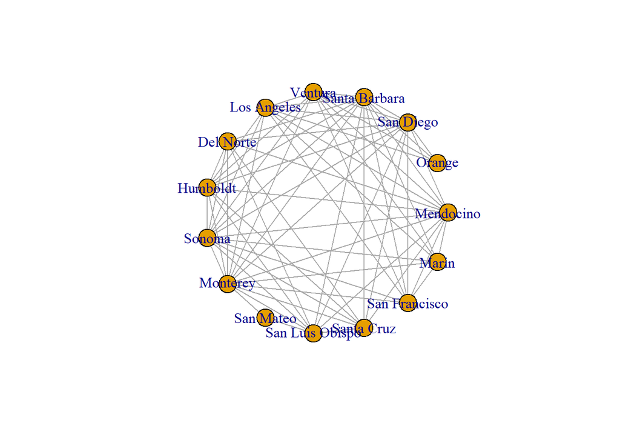

```
##       Mendocino          Orange       San Diego   Santa Barbara         Ventura
##              12               4              12              13              10
##     Los Angeles       Del Norte        Humboldt          Sonoma        Monterey
##              10               8              10              12              13
##       San Mateo San Luis Obispo      Santa Cruz   San Francisco           Marin
##               2               9               8               8               7
```

How many inter-county connections just from looking at the same organization working in multiple counties? (total counties: 15)

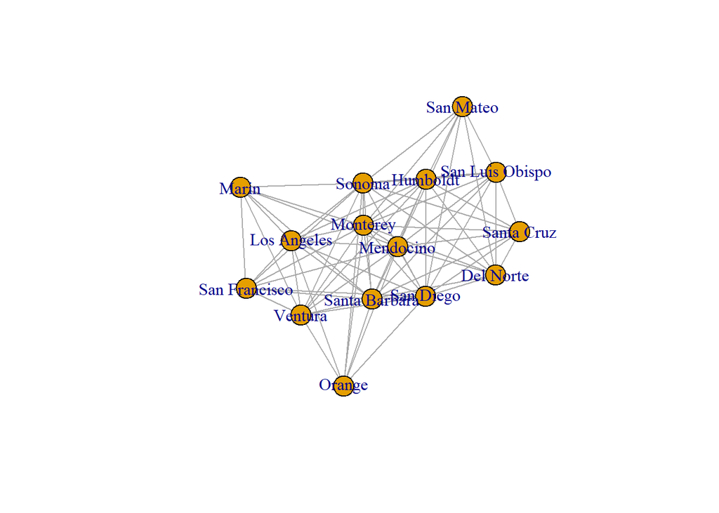

```
##       Mendocino          Orange       San Diego   Santa Barbara         Ventura
##              14               7              13              13              10
##     Los Angeles       Del Norte        Humboldt          Sonoma        Monterey
##              10               9              11              14              14
##       San Mateo San Luis Obispo      Santa Cruz   San Francisco           Marin
##               7               9               8               8               7
```

### bipartite plot

Just for fun…

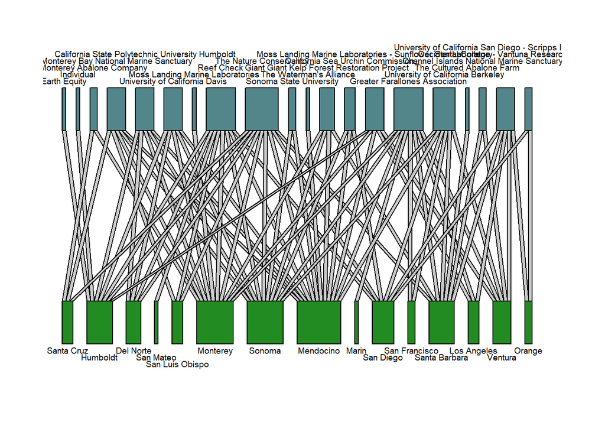

- be able to look at strength of ties, not just presence / absence (number of orgs collaborating, or something)
- break down the actor types beyond degree of participation in kelp-related issues
- build finer-scale ecological network

## 2. Information Source

**Survey question: “What are the main ways you learn about kelp forest-related issues?”**

Can I use the answer to this question to identify organizations / sites where people are actively in the water monitoring conditions and/or engaging in restoration? This will help set the scale of the SEN.

What is the **response rate?**

```
## [1] 0.9602273
```

Take a look at the different responses (only those with 3+ responses shown here). Lots of individuals directly observe conditions, a slightly smaller number collect and analyze data.

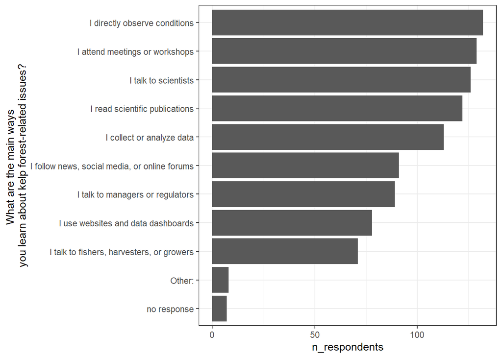

Lots of people also chose 2+ responses to this question.

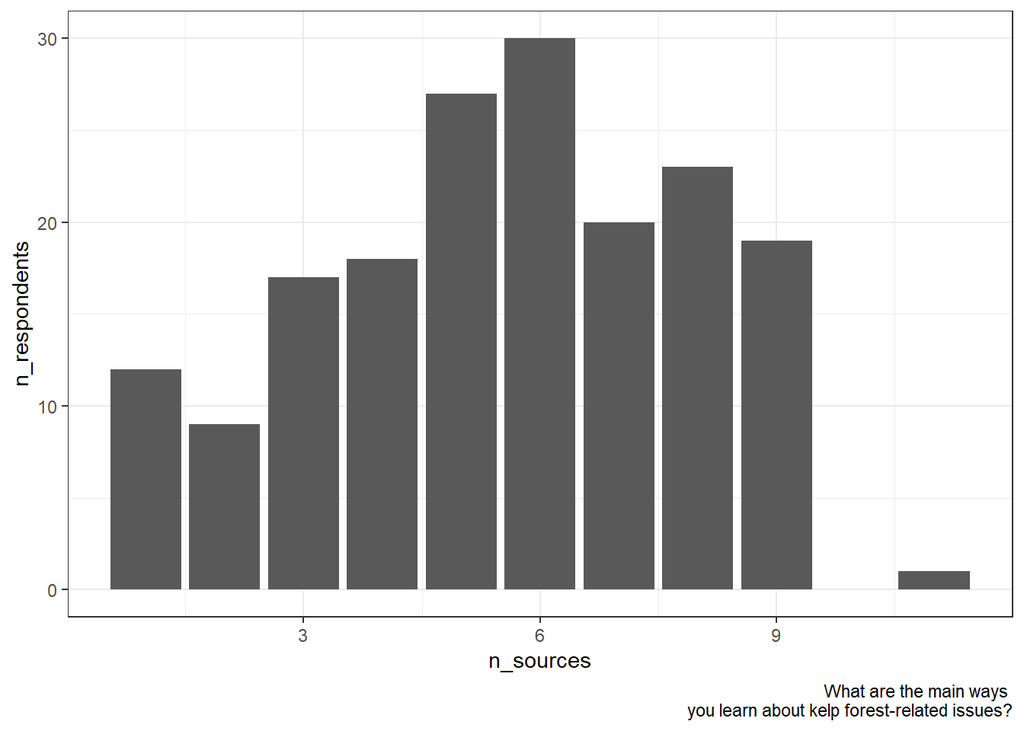

How many organizations do I have to track down, to link to specific sites within counties?

Number of organizations for….

1. people in group 1: 36
2. people in group 2: 43
3. people ONLY in group 1: 3
4. people ONLY in group 2: 10
5. people in both groups 1 and 2: 33

## 3. Type of involvement

**Survey Question: Which words or phrases best describe your involvement in kelp forest-related issues?**

### a. scale-setting

Can I use the answer to this question to identify organizations / sites where people are actively in the water monitoring conditions and/or engaging in restoration? This will help set the scale of the SEN.

What is the **response rate?** Lower than information source.

```
## [1] 0.7355372
```

What is the **response rate among those who provided location information?**

```
## [1] 1
```

What is the variation in how respondents are involved in kelp issues (tourism, research, etc)? <– is this a useful actor attribute to explore bonding v. bridging

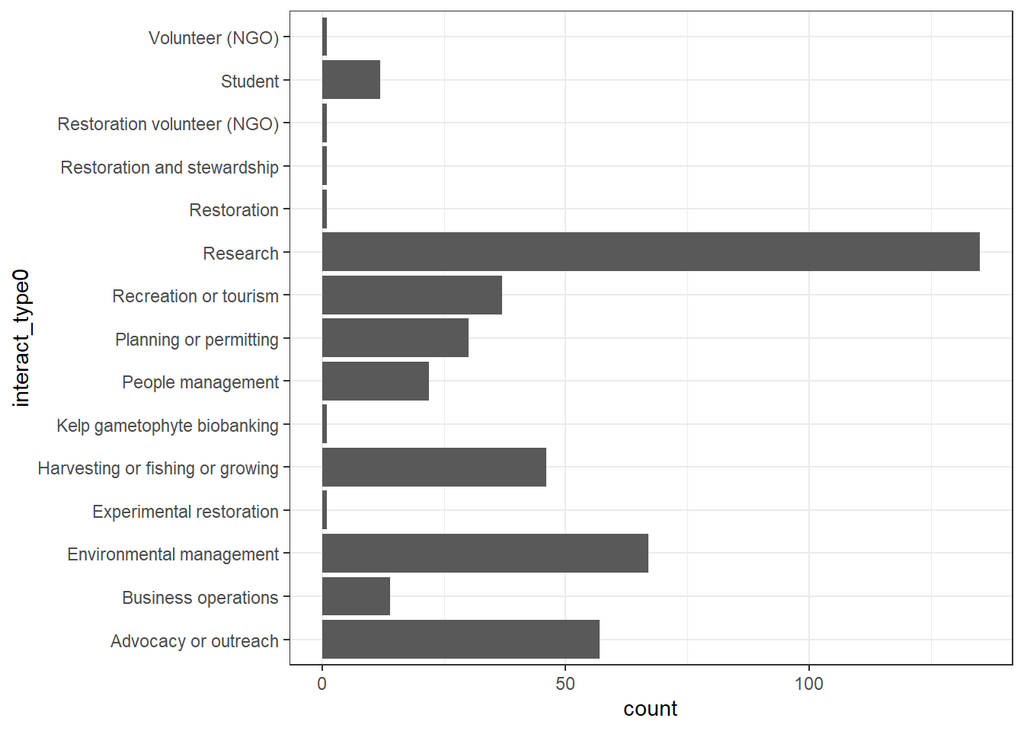

Most individuals chose 2+ ways of being involved.

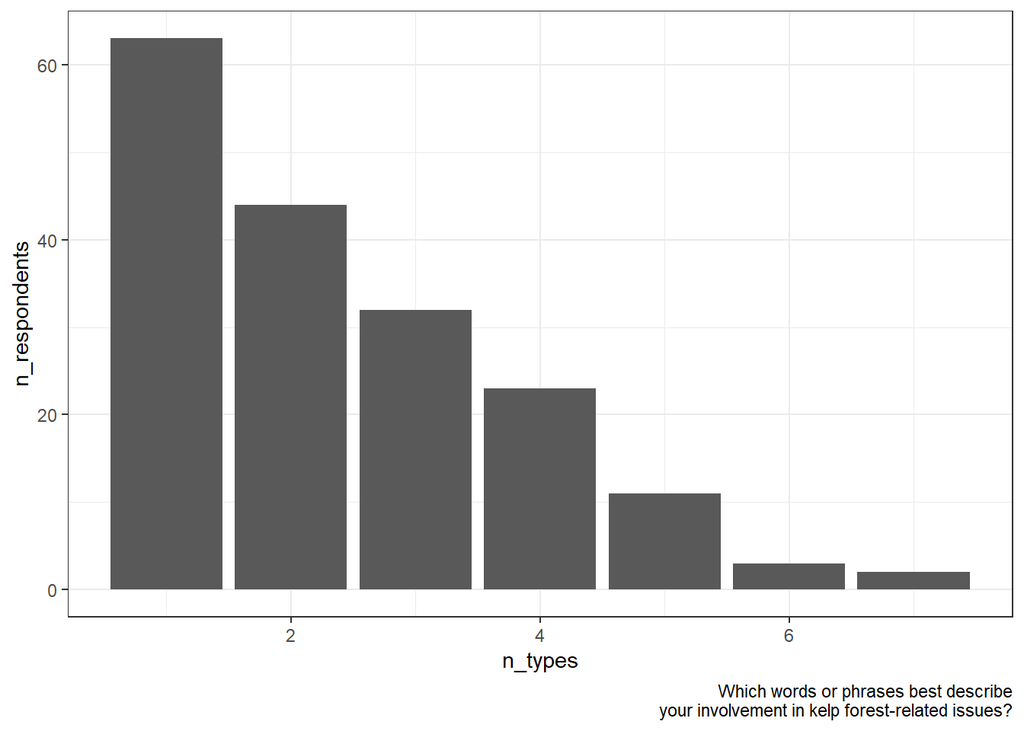

What proportion of individuals chose Restoration, Research, Harvesting/Fishing/Growing, or Recreation?

```
## [1] 0.8426966
```

How many organizations do I have to track down, to link to specific sites within counties?

```
## [1] 46
```

More organizations than when I used information source. Is this every organization in the survey?

```
## [1] TRUE
```

### b. is this a useful actor attribute to explore bonding v. bridging?

Which activities are commonly cited by the same individual? I’ve removed the singular responses to make it easier to see the other responses.

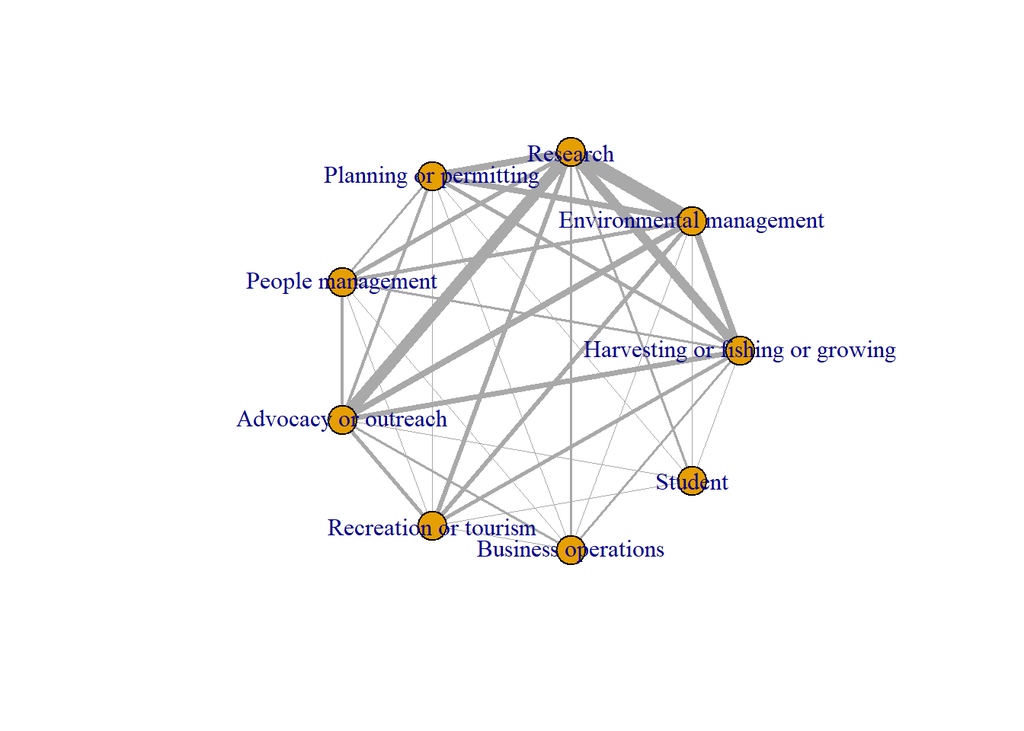

Which activities commonly take place within the same organization? I’ve removed the singular responses to make it easier to see the other responses. Research is commonly done in combination with other activities.

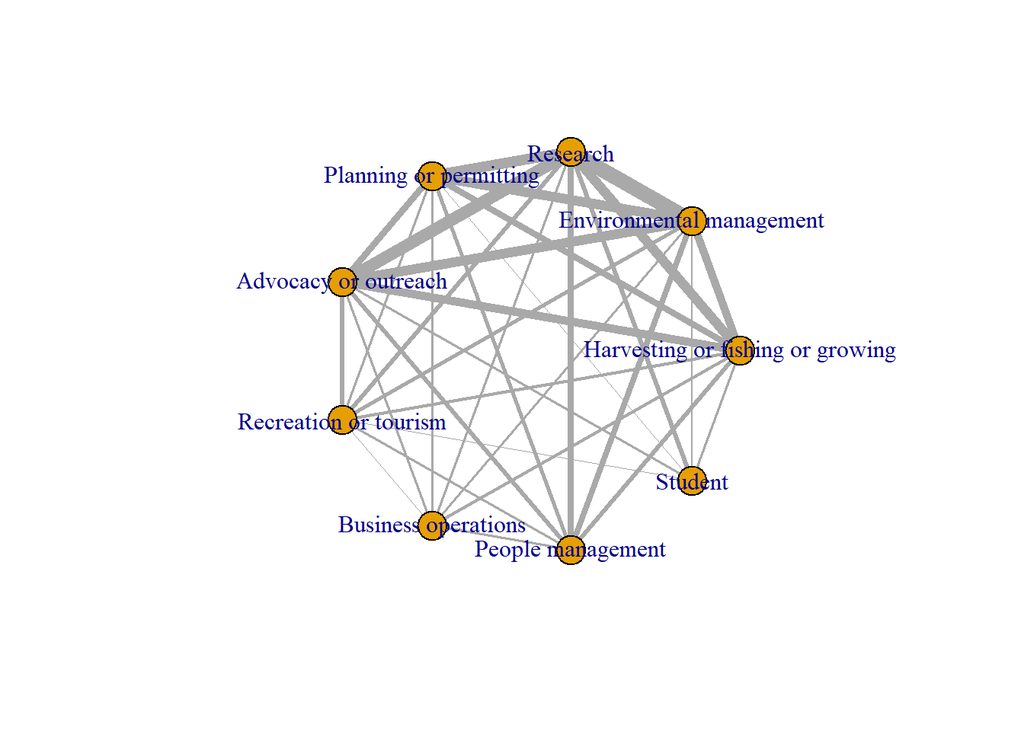

Just for fun…

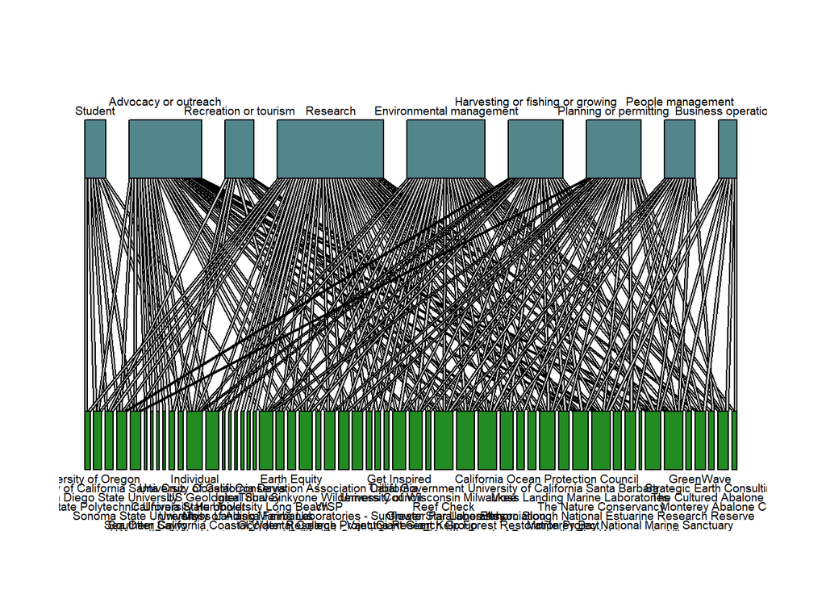

## 4. Level of involvement

**Survey Question: Which of the following statements best matches your level of involvement in kelp forest-related issues (including harvesting, management, advocacy, research, cultural uses, etc) in California?**

There should be variation in level of involvement to make it an interesting way to subset the network to explore existing v potential fit

What is the **response rate?**

```
## [1] 0.8677686
```

What is the **response rate for those who provided location information?**

```
## [1] 0.9827586
```

How much variation is there in responses by those who provided location information?

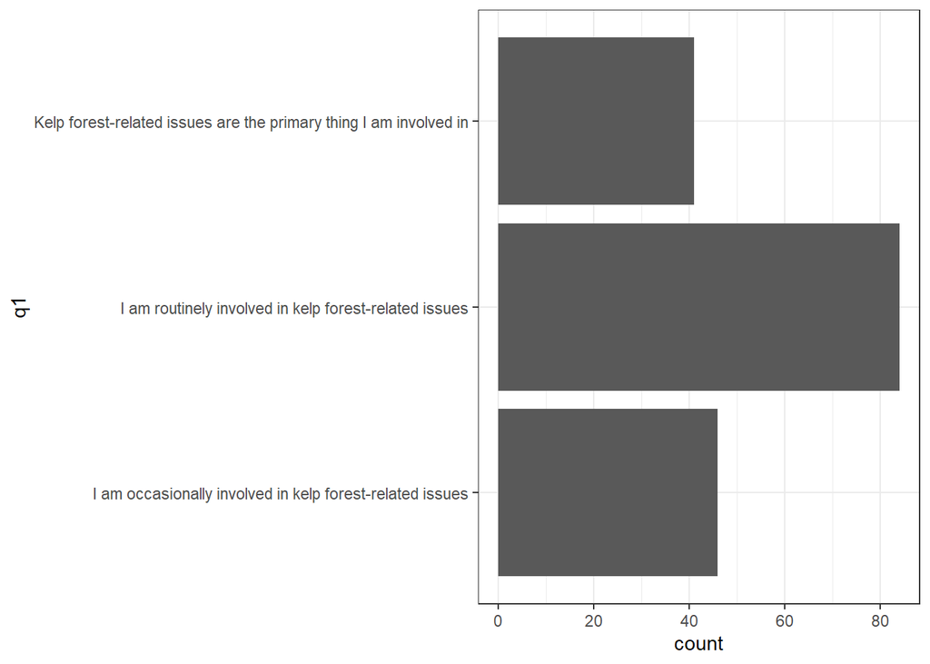

## 5. Combine 1-3 for scale-setting

Are there combinations of 1-3 that can help specify who is on the water for scale-setting?

#### involvement type x level of involvement

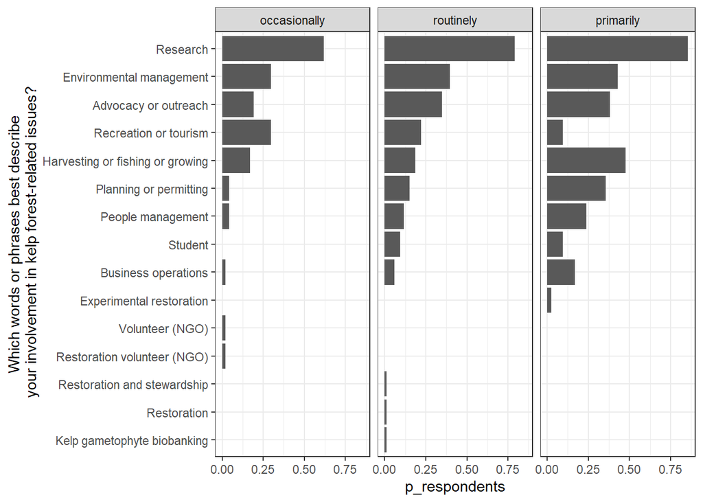

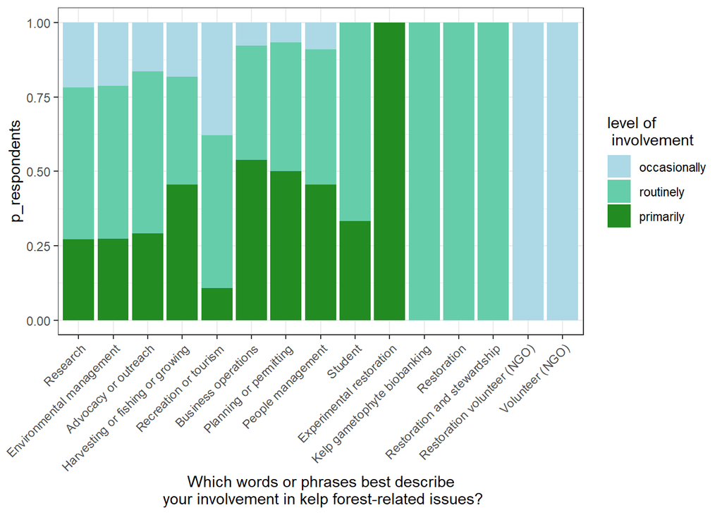

That’s actually kind of interesting. But not super helpful for scale setting.

#### info source x level of involvement

Could I use ‘level of involvement’ to limit my sample size of people who are directly interacting with kelp ecosystems? In other words, are some people who collect / analyze data, or who directly observe conditions, only occasionally involved in kelp forest related issues?

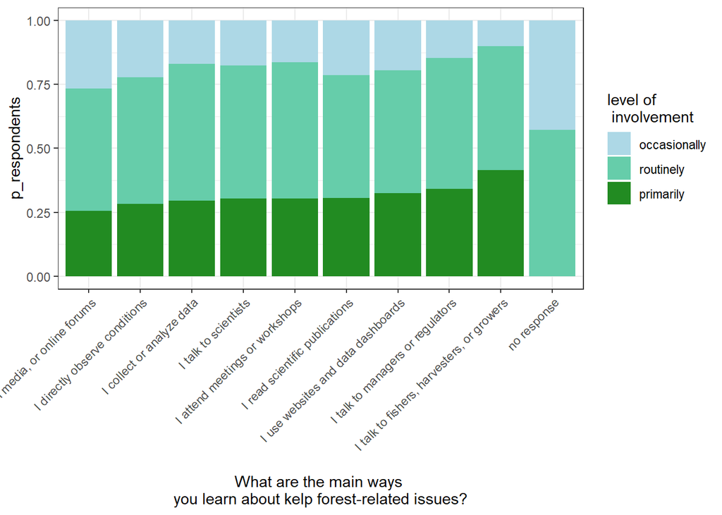

Answer is yes, there are a handful of respondents in these ‘first order’ information categories we could potentially leave out. What proportion of the ‘direct interaction’ information group are only occasionally involved in kelp forest-related issues?

```
## [1] 0.2470588
```

But do they represent unique organizations? Yes, 7 orgs.

```
## [1] 7
```

—————————- stopped here 2/7/2025 —————————-

#### info source x involvement type

As before, I’m grouping information responses as:

```r
info1d <- c("I collect or analyze data", "I actively do kelp restoration", "I study my restoration projects")
info2d <- c("Direct impact cultural uses","I directly observe conditions")
```

Because people could choose more than one response, I’m going to limit them to whichever comes first: data / restoration, direct observation / use, other.

## 6. Transformation Qs

What is the response rate and variation in response for the Question 8 Likert Scale questions on transformation? Variation in response among individuals from the same organization? <– is this a useful actor attribute to explore bonding v. bridging

**Response Rates** by question group:

1. human intervention in kelp forests

```
## # A tibble: 3 × 4
##   response_cat q1_restore_to_previous_state q2_no_interference q3_transform
##   <chr>                               <dbl>              <dbl>        <dbl>
## 1 Don't know                         0.0124            0.00826       0.0248
## 2 answered                           0.690             0.694         0.678
## 3 <NA>                               0.298             0.298         0.298
```

2. what restoration techniques should be focused on

```
## # A tibble: 3 × 3
##   response_cat q4_scale_up_current  q5_new
##   <chr>                      <dbl>   <dbl>
## 1 Don't know               0.00413 0.00826
## 2 answered                 0.698   0.694
## 3 <NA>                     0.298   0.298
```

3. risk

```
## # A tibble: 3 × 4
##   response_cat q6_prioritize_low_risk q7_high_risk_large_benefit q8_learn_more
##   <chr>                         <dbl>                      <dbl>         <dbl>
## 1 Don't know                   0.0289                     0.0413       0.00826
## 2 answered                     0.674                      0.661        0.694
## 3 <NA>                         0.298                      0.298        0.298
```

Distribution of responses:

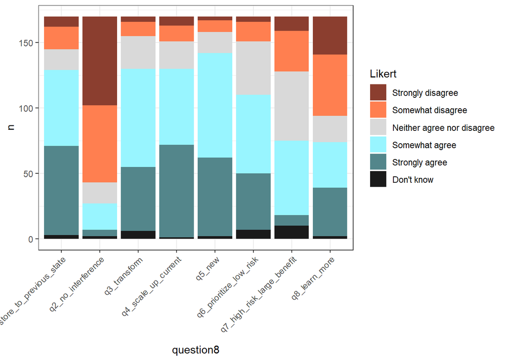

Variation in response within organizations?

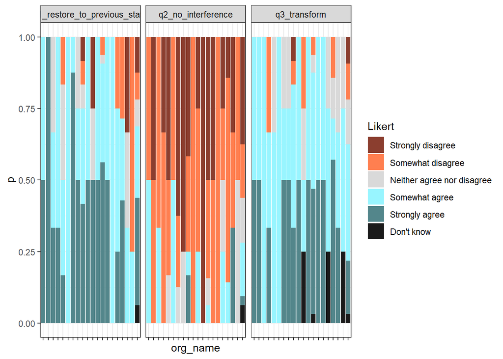

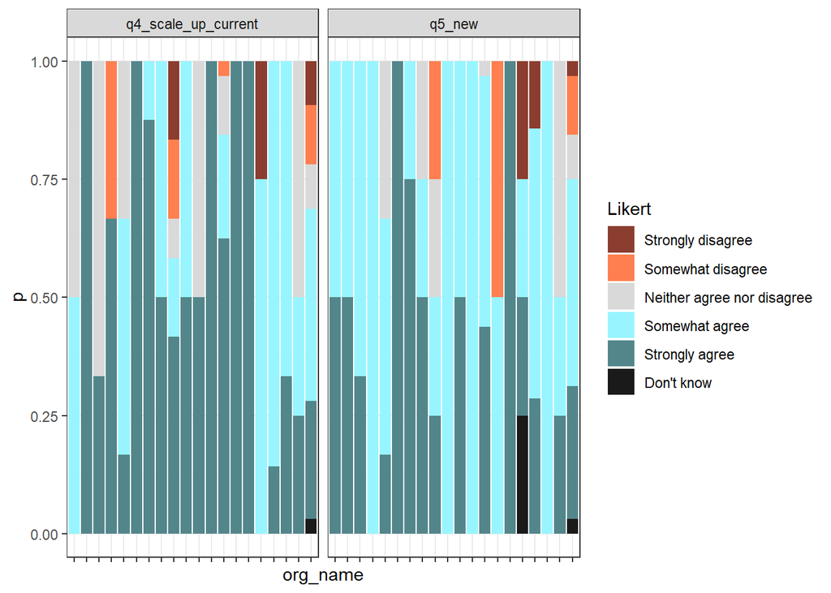

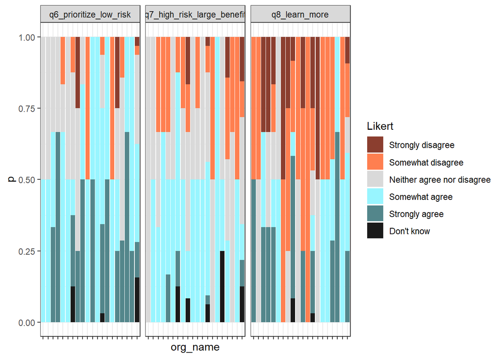